# Comparative Analysis of Supervised Learning Algorithms

### 6.2 KNN Classifier

#### 6.2.1 Wine Dataset

##### 6.2.1.1 Default Classifier

```
Confusion matrix, without normalization
[[1011  654]
 [ 473 2409]]
```

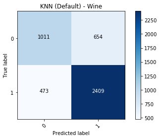

```python
Wine_knnclf =  KNeighborsClassifier(n_jobs=-1)
Wine_y_pred = cross_val_predict(Wine_knnclf, Wine_X_train, Wine_y_train, cv=cv, n_jobs=-1)

cnf_matrix = confusion_matrix(Wine_y_train, Wine_y_pred)
np.set_printoptions(precision=2)

# Plot non-normalized confusion matrix
plt.figure()
utils.plot_confusion_matrix(cnf_matrix, classes=[0,1],
                      title='KNN (Default) - Wine')
```

```python
modelid = "KNN (Default) - Wine"
prscore = precision_score(Wine_y_train, Wine_y_pred, average='binary')
rcscore = recall_score(Wine_y_train, Wine_y_pred, average='binary')
f1score = f1_score(Wine_y_train, Wine_y_pred)#, average='binary')

model_stats.append([modelid, prscore, rcscore, f1score])
print("Precision: "+str("{:.2f}".format(prscore))+", Recall: "+str("{:.2f}".format(rcscore))+", F1 Score: "+str("{:.2f}".format(f1score)))
```

```
Precision: 0.79, Recall: 0.84, F1 Score: 0.81
```

```python
#plot learning curve
utils.plot_learning_curve(Wine_knnclf, "KNN (Default) - Wine - Learning Curve", Wine_X_train, Wine_y_train, cv=cv, n_jobs=-1, exp_score=0.8, train_sizes=np.linspace(0.05, 1.0, 10), ylim=[0.5,1])
```

[output not shown]

##### 6.2.1.2 Hyperparameter Tuning - Iteration 1

```python
param_grid = {'n_neighbors':np.arange(30,80,2), 'leaf_size':np.arange(1,50,5)}

Wine_knngs= GridSearchCV(Wine_knnclf,param_grid, cv=cv, scoring='f1', n_jobs=-1)
Wine_knngs.fit(Wine_X_train,Wine_y_train)
```

```
GridSearchCV(cv=StratifiedKFold(n_splits=10, random_state=1, shuffle=True),
             error_score=nan,
             estimator=KNeighborsClassifier(algorithm='auto', leaf_size=30,
                                            metric='minkowski',
                                            metric_params=None, n_jobs=-1,
                                            n_neighbors=5, p=2,
                                            weights='uniform'),
             iid='deprecated', n_jobs=-1,
             param_grid={'leaf_size': array([ 1,  6, 11, 16, 21, 26, 31, 36, 41, 46]),
                         'n_neighbors': array([30, 32, 34, 36, 38, 40, 42, 44, 46, 48, 50, 52, 54, 56, 58, 60, 62,
       64, 66, 68, 70, 72, 74, 76, 78])},
             pre_dispatch='2*n_jobs', refit=True, return_train_score=False,
             scoring='f1', verbose=0)
```

```python
print("Best Score:" + str(Wine_knngs.best_score_))
print("Best Parameters: " + str(Wine_knngs.best_params_))
print("Best Estimator: " + str(Wine_knngs.best_estimator_))
```

```
Best Score:0.8107689598683516
Best Parameters: {'leaf_size': 1, 'n_neighbors': 56}
Best Estimator: KNeighborsClassifier(algorithm='auto', leaf_size=1, metric='minkowski',
                     metric_params=None, n_jobs=-1, n_neighbors=56, p=2,
                     weights='uniform')
```

```
Confusion matrix, without normalization
[[ 929  736]
 [ 415 2467]]
```

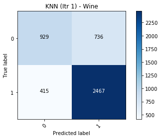

```python
Wine_knnclf =  KNeighborsClassifier(n_neighbors=Wine_knngs.best_params_["n_neighbors"], leaf_size=Wine_knngs.best_params_["leaf_size"], n_jobs=-1)

Wine_y_pred = cross_val_predict(Wine_knnclf, Wine_X_train, Wine_y_train, cv=cv, n_jobs=-1)

cnf_matrix = confusion_matrix(Wine_y_train, Wine_y_pred)
np.set_printoptions(precision=2)

# Plot non-normalized confusion matrix
plt.figure()
utils.plot_confusion_matrix(cnf_matrix, classes=[0,1],
                      title='KNN (Itr 1) - Wine')
```

```python
modelid = "KNN (Itr 1) - Wine"
prscore = precision_score(Wine_y_train, Wine_y_pred, average='binary')
rcscore = recall_score(Wine_y_train, Wine_y_pred, average='binary')
f1score = f1_score(Wine_y_train, Wine_y_pred)#, average='binary')

model_stats.append([modelid, prscore, rcscore, f1score])
print("Precision: "+str("{:.2f}".format(prscore))+", Recall: "+str("{:.2f}".format(rcscore))+", F1 Score: "+str("{:.2f}".format(f1score)))
```

```
Precision: 0.77, Recall: 0.86, F1 Score: 0.81
```

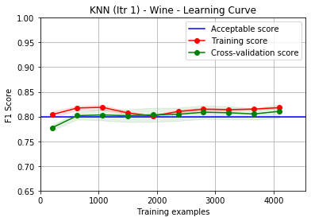

```python
#plot learning curve
utils.plot_learning_curve(Wine_knnclf, "KNN (Itr 1) - Wine - Learning Curve", Wine_X_train, Wine_y_train, cv=cv, n_jobs=-1, exp_score=0.8, train_sizes=np.linspace(0.05, 1.0, 10), ylim=[0.65,1])
```

##### 6.2.1.3 Hyperparameter Tuning - Iteration 2

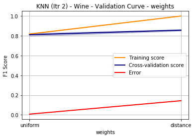

```python
parameter_range = ['uniform','distance']
param_name = "weights"

utils.plot_validation_curve(Wine_knnclf, Wine_X_train, Wine_y_train, param_name, parameter_range, cv=cv, n_jobs=-1,
                      title="KNN (Itr 2) - Wine - Validation Curve - weights", xlabel=param_name, ylim= (0.1, 1.1))
```

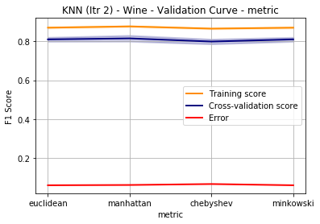

```python
parameter_range =['euclidean', 'manhattan', 'chebyshev', 'minkowski', 'mahalanobis']
param_name = "metric"

utils.plot_validation_curve(KNeighborsClassifier(), Wine_X_train, Wine_y_train, param_name, parameter_range, cv=cv, n_jobs=-1,
                      title="KNN (Itr 2) - Wine - Validation Curve - metric", xlabel=param_name, ylim= (0.1, 1.1))
```

```
Confusion matrix, without normalization
[[ 856  809]
 [ 392 2490]]
```

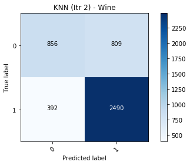

```python
Wine_knnclf =  KNeighborsClassifier(n_neighbors=117, n_jobs=-1)

Wine_y_pred = cross_val_predict(Wine_knnclf, Wine_X_train, Wine_y_train, cv=cv, n_jobs=-1)

cnf_matrix = confusion_matrix(Wine_y_train, Wine_y_pred)
np.set_printoptions(precision=2)

# Plot non-normalized confusion matrix
plt.figure()
utils.plot_confusion_matrix(cnf_matrix, classes=[0,1],
                      title='KNN (Itr 2) - Wine')
```

```python
modelid = "KNN (Itr 2) - Wine"
prscore = precision_score(Wine_y_train, Wine_y_pred, average='binary')
rcscore = recall_score(Wine_y_train, Wine_y_pred, average='binary')
f1score = f1_score(Wine_y_train, Wine_y_pred, average='binary')

model_stats.append([modelid, prscore, rcscore, f1score])
print("Precision: "+str("{:.2f}".format(prscore))+", Recall: "+str("{:.2f}".format(rcscore))+", F1 Score: "+str("{:.2f}".format(f1score)))
```

```
Precision: 0.75, Recall: 0.86, F1 Score: 0.81
```

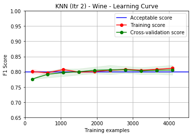

```python
#plot learning curve
utils.plot_learning_curve(Wine_knnclf, "KNN (Itr 2) - Wine - Learning Curve", Wine_X_train, Wine_y_train, cv=cv, n_jobs=-1, exp_score=0.8, train_sizes=np.linspace(0.05, 1.0, 10), ylim=[0.65,1])
```

##### 6.2.1.4 Test Set Validation

```
Confusion matrix, without normalization
[[ 220  499]
 [  60 1171]]
```

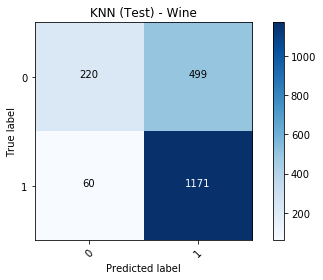

```
Precision: 0.70, Recall: 0.95, F1 Score: 0.81, Train Time: 14.48, Test Time: 217.42
```

```python
t_start = time.time()*1000.0
Wine_knnclf = Wine_knnclf.fit(Wine_X_train, Wine_y_train)
t_stop = time.time()*1000.0
traintime = t_stop - t_start

t_start = time.time()*1000.0
Wine_y_pred = (Wine_knnclf.predict_proba(Wine_X_test)[:,1] >= 0.4).astype(bool)
t_stop = time.time()*1000.0
testtime = t_stop - t_start

cnf_matrix = confusion_matrix(Wine_y_test, Wine_y_pred)
np.set_printoptions(precision=2)

# Plot non-normalized confusion matrix
plt.figure()
utils.plot_confusion_matrix(cnf_matrix, classes=[0,1], title='KNN (Test) - Wine')

modelid = "KNN (Test) - Wine"
prscore = precision_score(Wine_y_test, Wine_y_pred, average='binary')
rcscore = recall_score(Wine_y_test, Wine_y_pred, average='binary')
f1score = f1_score(Wine_y_test, Wine_y_pred, average='binary')

model_stats.append([modelid, prscore, rcscore, f1score, traintime, testtime])
print("Precision: "+str("{:.2f}".format(prscore))+", Recall: "+str("{:.2f}".format(rcscore))+", F1 Score: "+str("{:.2f}".format(f1score))+", Train Time: "+str("{:.2f}".format(traintime))+", Test Time: "+str("{:.2f}".format(testtime)))
```

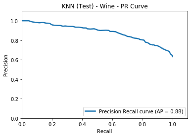

```
Optimal Threshold:
0.4700854700854701
Maximized F1 score:
0.8147329650092081
```

```python
utils.plot_pr_curve(Wine_knnclf, Wine_X_test, Wine_y_test, "KNN (Test) - Wine - PR Curve", False)
```

#### 6.2.2 Census Dataset

##### 6.2.2.1 Default Classifier

```
Confusion matrix, without normalization
[[14315  1570]
 [ 2169  3059]]
```

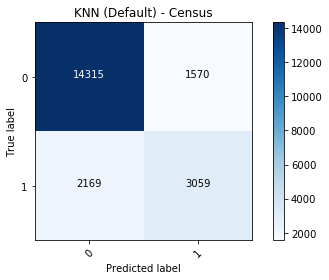

```python
Census_knnclf =  KNeighborsClassifier(n_jobs=-1)

Census_y_pred = cross_val_predict(Census_knnclf, Census_X_train, Census_y_train, cv=cv, n_jobs=-1)

cnf_matrix = confusion_matrix(Census_y_train, Census_y_pred)
np.set_printoptions(precision=2)

# Plot non-normalized confusion matrix
plt.figure()
utils.plot_confusion_matrix(cnf_matrix, classes=[0,1],
                      title='KNN (Default) - Census')
```

```python
modelid = "KNN (Default) - Census"
prscore = precision_score(Census_y_train, Census_y_pred, average='binary')
rcscore = recall_score(Census_y_train, Census_y_pred, average='binary')
f1score = f1_score(Census_y_train, Census_y_pred, average='binary')

model_stats.append([modelid, prscore, rcscore, f1score])
print("Precision: "+str("{:.2f}".format(prscore))+", Recall: "+str("{:.2f}".format(rcscore))+", F1 Score: "+str("{:.2f}".format(f1score)))
```

```
Precision: 0.66, Recall: 0.59, F1 Score: 0.62
```

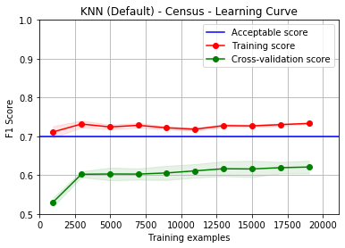

```python
#plot learning curve
utils.plot_learning_curve(Census_knnclf, "KNN (Default) - Census - Learning Curve", Census_X_train, Census_y_train, cv=cv, n_jobs=-1, exp_score=0.7, train_sizes=np.linspace(0.05, 1.0, 10), ylim=[0.5,1])
```

##### 6.2.2.2 Hyperparameter Tuning - Iteration 1

```python
param_grid = {'n_neighbors':np.arange(30,80,2), 'leaf_size':np.arange(1,50,5)}

Census_knngs= GridSearchCV(Census_knnclf,param_grid, cv=cv, scoring='f1', n_jobs=-1)
Census_knngs.fit(Census_X_train,Census_y_train)
```

```
GridSearchCV(cv=StratifiedKFold(n_splits=10, random_state=1, shuffle=True),
             error_score=nan,
             estimator=KNeighborsClassifier(algorithm='auto', leaf_size=30,
                                            metric='minkowski',
                                            metric_params=None, n_jobs=-1,
                                            n_neighbors=5, p=2,
                                            weights='uniform'),
             iid='deprecated', n_jobs=-1,
             param_grid={'leaf_size': array([ 1,  6, 11, 16, 21, 26, 31, 36, 41, 46]),
                         'n_neighbors': array([30, 32, 34, 36, 38, 40, 42, 44, 46, 48, 50, 52, 54, 56, 58, 60, 62,
       64, 66, 68, 70, 72, 74, 76, 78])},
             pre_dispatch='2*n_jobs', refit=True, return_train_score=False,
             scoring='f1', verbose=0)
```

```python
print("Best Score:" + str(Census_knngs.best_score_))
print("Best Parameters: " + str(Census_knngs.best_params_))
print("Best Estimator: " + str(Census_knngs.best_estimator_))
```

```
Best Score:0.6231341420851927
Best Parameters: {'leaf_size': 21, 'n_neighbors': 36}
Best Estimator: KNeighborsClassifier(algorithm='auto', leaf_size=21, metric='minkowski',
                     metric_params=None, n_jobs=-1, n_neighbors=36, p=2,
                     weights='uniform')
```

```
Confusion matrix, without normalization
[[14709  1176]
 [ 2329  2899]]
```

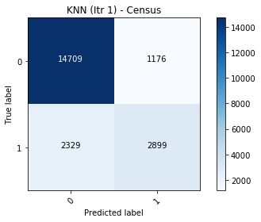

```python
Census_knnclf =  KNeighborsClassifier(n_neighbors=Census_knngs.best_params_["n_neighbors"], leaf_size=Census_knngs.best_params_["leaf_size"], n_jobs=-1)

Census_y_pred = cross_val_predict(Census_knnclf, Census_X_train, Census_y_train, cv=cv, n_jobs=-1)

cnf_matrix = confusion_matrix(Census_y_train, Census_y_pred)
np.set_printoptions(precision=2)

# Plot non-normalized confusion matrix
plt.figure()
utils.plot_confusion_matrix(cnf_matrix, classes=[0,1],
                      title='KNN (Itr 1) - Census')
```

```python
modelid = "KNN (Itr 1) - Census"
prscore = precision_score(Census_y_train, Census_y_pred, average='binary')
rcscore = recall_score(Census_y_train, Census_y_pred, average='binary')
f1score = f1_score(Census_y_train, Census_y_pred, average='binary')

model_stats.append([modelid, prscore, rcscore, f1score])
print("Precision: "+str("{:.2f}".format(prscore))+", Recall: "+str("{:.2f}".format(rcscore))+", F1 Score: "+str("{:.2f}".format(f1score)))
```

```
Precision: 0.71, Recall: 0.55, F1 Score: 0.62
```

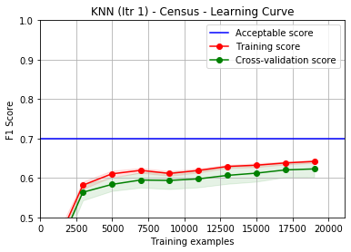

```python
#plot learning curve
utils.plot_learning_curve(Census_knnclf, "KNN (Itr 1) - Census - Learning Curve", Census_X_train, Census_y_train, cv=cv, n_jobs=-1, exp_score=0.7, train_sizes=np.linspace(0.05, 1.0, 10), ylim=[0.5,1])
```

##### 6.2.2.3 Hyperparameter Tuning - Iteration 2

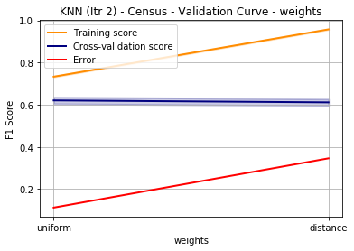

```python
parameter_range =['uniform', 'distance']
param_name = "weights"

utils.plot_validation_curve(KNeighborsClassifier(), Census_X_train, Census_y_train, param_name, parameter_range, cv=cv, n_jobs=-1,
                      title="KNN (Itr 2) - Census - Validation Curve - weights", xlabel=param_name, ylim= (0.1, 1.1))
```

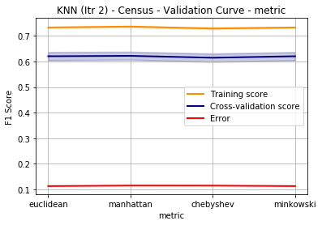

```python
parameter_range =['euclidean', 'manhattan', 'chebyshev', 'minkowski', 'mahalanobis']
param_name = "metric"

utils.plot_validation_curve(KNeighborsClassifier(), Census_X_train, Census_y_train, param_name, parameter_range, cv=cv, n_jobs=-1,
                      title="KNN (Itr 2) - Census - Validation Curve - metric", xlabel=param_name, ylim= (0.1, 1.1))
```

```
Confusion matrix, without normalization
[[14526  1359]
 [ 2155  3073]]
```

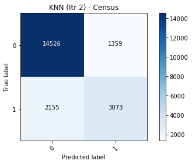

```python
Census_knnclf =  KNeighborsClassifier(n_neighbors=13, n_jobs=-1)

Census_y_pred = cross_val_predict(Census_knnclf, Census_X_train, Census_y_train, cv=cv, n_jobs=-1)

cnf_matrix = confusion_matrix(Census_y_train, Census_y_pred)
np.set_printoptions(precision=2)

# Plot non-normalized confusion matrix
plt.figure()
utils.plot_confusion_matrix(cnf_matrix, classes=[0,1],
                      title='KNN (Itr 2) - Census')
```

```python
modelid = "KNN (Itr 2) - Census"
prscore = precision_score(Census_y_train, Census_y_pred, average='binary')
rcscore = recall_score(Census_y_train, Census_y_pred, average='binary')
f1score = f1_score(Census_y_train, Census_y_pred, average='binary')

model_stats.append([modelid, prscore, rcscore, f1score])
print("Precision: "+str("{:.2f}".format(prscore))+", Recall: "+str("{:.2f}".format(rcscore))+", F1 Score: "+str("{:.2f}".format(f1score)))
```

```
Precision: 0.69, Recall: 0.59, F1 Score: 0.64
```

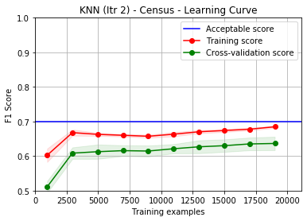

```python
#plot learning curve
utils.plot_learning_curve(Census_knnclf, "KNN (Itr 2) - Census - Learning Curve", Census_X_train, Census_y_train, cv=cv, n_jobs=-1, exp_score=0.7, train_sizes=np.linspace(0.05, 1.0, 10), ylim=[0.5,1])
```

##### 6.2.2.4 Test Set Validation

```
Confusion matrix, without normalization
[[6028  741]
 [ 709 1571]]
```

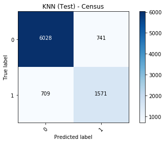

```
Precision: 0.68, Recall: 0.69, F1 Score: 0.68, Train Time: 577.58, Test Time: 1330.11
```

```python
t_start = time.time()*1000.0
Census_knnclf = Census_knnclf.fit(Census_X_train, Census_y_train)
t_stop = time.time()*1000.0
traintime = t_stop - t_start

t_start = time.time()*1000.0
Census_y_pred = (Census_knnclf.predict_proba(Census_X_test)[:,1] >= 0.4).astype(bool)
t_stop = time.time()*1000.0
testtime = t_stop - t_start

cnf_matrix = confusion_matrix(Census_y_test, Census_y_pred)
np.set_printoptions(precision=2)

# Plot non-normalized confusion matrix
plt.figure()
utils.plot_confusion_matrix(cnf_matrix, classes=[0,1], title='KNN (Test) - Census')

modelid = "KNN (Test) - Census"
prscore = precision_score(Census_y_test, Census_y_pred, average='binary')
rcscore = recall_score(Census_y_test, Census_y_pred, average='binary')
f1score = f1_score(Census_y_test, Census_y_pred, average='binary')

model_stats.append([modelid, prscore, rcscore, f1score, traintime, testtime])
print("Precision: "+str("{:.2f}".format(prscore))+", Recall: "+str("{:.2f}".format(rcscore))+", F1 Score: "+str("{:.2f}".format(f1score))+", Train Time: "+str("{:.2f}".format(traintime))+", Test Time: "+str("{:.2f}".format(testtime)))
```

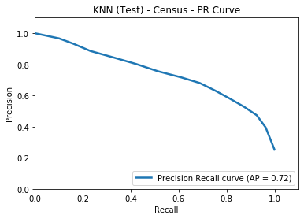

```
Optimal Threshold:
0.38461538461538464
Maximized F1 score:
0.6865253898440623
```

```python
utils.plot_pr_curve(Census_knnclf, Census_X_test, Census_y_test, "KNN (Test) - Census - PR Curve", False)
```

## 6.2.3 Observations

- Biased split of train and cv dataset is not possible due to use of stratified Kfold sampling.
- Sensitivity to noisy or irrelevant attributes is not possible because features are scaled.

**Performance of Test Set:** Wine Dataset: Performance of tuned model on the held-out test dataset was up to the expected value. F1 score on test data was 0.81 and Average Precision for PR curve was 0.88.  
Census Dataset: Performance of tuned model on the held-out test dataset was around the expected value. F1 score on test data was 0.68 and Average Precision for PR curve was 0.72.  
Based on the PR curves we can conclude that both models have generalized well.

================================================================================================================

### 6.3 Decision Tree Classifier

### 6.3.1 Wine Dataset

##### 6.3.1.1 Default Classifier

```
Confusion matrix, without normalization
[[1131  534]
 [ 534 2348]]
```

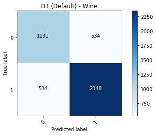

```python
Wine_dtclf =  DecisionTreeClassifier(random_state=1)

Wine_y_pred = cross_val_predict(Wine_dtclf, Wine_X_train, Wine_y_train, cv=cv, n_jobs=-1)

cnf_matrix = confusion_matrix(Wine_y_train, Wine_y_pred)
np.set_printoptions(precision=2)

# Plot non-normalized confusion matrix
plt.figure()
utils.plot_confusion_matrix(cnf_matrix, classes=[0,1],
                      title='DT (Default) - Wine')
```

```python
modelid = "DT (Default) - Wine"
prscore = precision_score(Wine_y_train, Wine_y_pred, average='binary')
rcscore = recall_score(Wine_y_train, Wine_y_pred, average='binary')
f1score = f1_score(Wine_y_train, Wine_y_pred, average='binary')

model_stats.append([modelid, prscore, rcscore, f1score])
print("Precision: "+str("{:.2f}".format(prscore))+", Recall: "+str("{:.2f}".format(rcscore))+", F1 Score: "+str("{:.2f}".format(f1score)))
```

```
Precision: 0.81, Recall: 0.81, F1 Score: 0.81
```

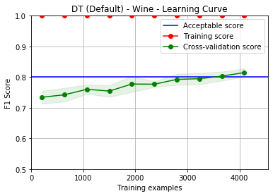

```python
#plot learning curve
utils.plot_learning_curve(Wine_dtclf, "DT (Default) - Wine - Learning Curve", Wine_X_train, Wine_y_train, cv=cv, n_jobs=-1, exp_score=0.8, train_sizes=np.linspace(0.05, 1.0, 10), ylim=[0.5,1])
```

##### 6.3.1.2 Hyperparameter Tuning - Iteration 1

```python
criterion = ['gini', 'entropy']
param_grid = [{'criterion':criterion}]

Wine_dtgs= GridSearchCV(Wine_dtclf,param_grid, cv=cv, scoring='f1', n_jobs=-1)
Wine_dtgs.fit(Wine_X_train,Wine_y_train)
```

```
GridSearchCV(cv=StratifiedKFold(n_splits=10, random_state=1, shuffle=True),
             error_score=nan,
             estimator=DecisionTreeClassifier(ccp_alpha=0.0, class_weight=None,
                                              criterion='gini', max_depth=None,
                                              max_features=None,
                                              max_leaf_nodes=None,
                                              min_impurity_decrease=0.0,
                                              min_impurity_split=None,
                                              min_samples_leaf=1,
                                              min_samples_split=2,
                                              min_weight_fraction_leaf=0.0,
                                              presort='deprecated',
                                              random_state=1, splitter='best'),
             iid='deprecated', n_jobs=-1,
             param_grid=[{'criterion': ['gini', 'entropy']}],
             pre_dispatch='2*n_jobs', refit=True, return_train_score=False,
             scoring='f1', verbose=0)
```

```python
print("Best Score:" + str(Wine_dtgs.best_score_))
print("Best Parameters: " + str(Wine_dtgs.best_params_))
print("Best Estimator: " + str(Wine_dtgs.best_estimator_))
```

```
Best Score:0.818212095078658
Best Parameters: {'criterion': 'entropy'}
Best Estimator: DecisionTreeClassifier(ccp_alpha=0.0, class_weight=None, criterion='entropy',
                       max_depth=None, max_features=None, max_leaf_nodes=None,
                       min_impurity_decrease=0.0, min_impurity_split=None,
                       min_samples_leaf=1, min_samples_split=2,
                       min_weight_fraction_leaf=0.0, presort='deprecated',
                       random_state=1, splitter='best')
```

```
Confusion matrix, without normalization
[[1141  524]
 [ 524 2358]]
```

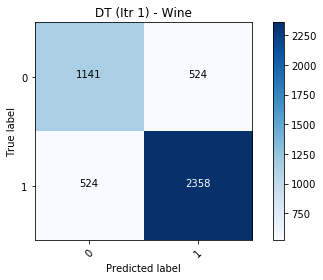

```python
Wine_dtclf =  DecisionTreeClassifier(criterion=Wine_dtgs.best_params_["criterion"],
                       random_state=1)

Wine_y_pred = cross_val_predict(Wine_dtclf, Wine_X_train, Wine_y_train, cv=cv, n_jobs=-1)

cnf_matrix = confusion_matrix(Wine_y_train, Wine_y_pred)
np.set_printoptions(precision=2)

# Plot non-normalized confusion matrix
plt.figure()
utils.plot_confusion_matrix(cnf_matrix, classes=[0,1],
                      title='DT (Itr 1) - Wine')
```

```python
modelid = "DT (Itr 1) - Wine"
prscore = precision_score(Wine_y_train, Wine_y_pred, average='binary')
rcscore = recall_score(Wine_y_train, Wine_y_pred, average='binary')
f1score = f1_score(Wine_y_train, Wine_y_pred, average='binary')

model_stats.append([modelid, prscore, rcscore, f1score])
print("Precision: "+str("{:.2f}".format(prscore))+", Recall: "+str("{:.2f}".format(rcscore))+", F1 Score: "+str("{:.2f}".format(f1score)))
```

```
Precision: 0.82, Recall: 0.82, F1 Score: 0.82
```

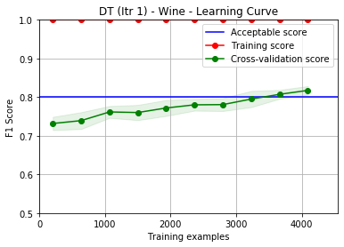

```python
#plot learning curve
utils.plot_learning_curve(Wine_dtclf, "DT (Itr 1) - Wine - Learning Curve", Wine_X_train, Wine_y_train, cv=cv, n_jobs=-1, exp_score=0.8, train_sizes=np.linspace(0.05, 1.0, 10), ylim=[0.5,1])
```